# Final Project

Ike, Shyni and Manish

June 19, 2019

World football has experienced something of a transformation over the past 15 years, an increase in investment, increased attendance, increased revenue from a variety of different sources and there are encouraging evidence that each them are adopting different methods to remain competitive. It is well known that some teams need a certain degree of competitive balance in order to survive and flourish. Player profitability is a great way to not only remain competitive but it is also a good way for a low-ranking team to achieve rapid success. When we consider player profitability, what does that actually represent? Player profitability would be a method of determining the success or Potential of a certain player based on a set of predetermined characteristics. With so much at stake and the transfer fees for players constantly increasing, the search for talent has become more desperate with football teams fighting to achieve the best talent.

Effective sports analytics has greatly helped in baseball and basketball in determining the competitive characteristics using statistics. On the other hand, analytics for world football is fairly limited; it will be beneficial to establish a few analytics methods that may help better provide insightful results. The purpose of our analysis is to predict the potential of a player surrounding certain characteristics that are highlighted for currently successful players in those positions.

Dataset

The data was taken from the FIFA 19 complete player data. It consist of 18207 attributes and 89 variables like Age, Nationality, Overall, Potential, Club, Value, Wage, Preferred Foot, International Reputation, Weak Foot, Skill Moves, Work Rate, Position, Jersey Number, Joined, Loaned From, Contract Valid Until, Height, Weight, LS, ST, RS, LW, LF, CF, RF, RW, LAM, CAM, RAM, LM, LCM, CM, RCM, RM, LWB, LDM, CDM, RDM, RWB, LB, LCB, CB, RCB, RB, Crossing, Finishing, Heading, Accuracy, Short-Passing, Volleys, Dribbling, Curve, FK-Accuracy, Long-Passing, Ball-Control, Acceleration, Sprint-Speed, Agility, Reactions, Balance, Shot-Power, Jumping, Stamina, Strength, Long-Shots, Aggression, Interceptions, Positioning, Vision, Penalties, Composure, Marking, Standing-Tackle, Sliding-Tackle, GK-Diving, GK-Handling, GK-Kicking, GK-Positioning, GK-Reflexes, and Release Clause.

```r
setwd("C:\\Users\\Manish Kumar\\Desktop\\Masters\\Fisher\\Sports Analytics\\Final Project\\2019")

fifa2019 <- read_csv("data.csv")
```

Analysis

Q: What is the distribution of the age of the players? How is it related to the average rating?

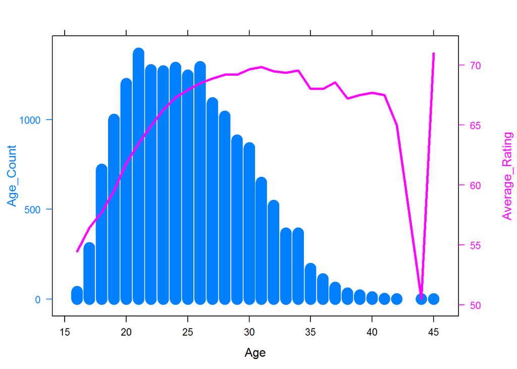

```r
#Age Density of FIFA Players

fifa2019_unique <-
  fifa2019 %>%
  group_by(Name) %>%
  top_n(n = 1, wt = ID) %>%
  as.data.frame()

age_rating <- fifa2019_unique %>%
              group_by(Age) %>%
              summarise(Age_Count = n(),Average_Rating = mean(Overall))

obj1 <- xyplot(Age_Count ~ Age, age_rating, type = "h", lwd = 15)
obj2 <- xyplot(Average_Rating ~ Age, age_rating, type = "l", lwd = 3)


doubleYScale(obj1, obj2,add.ylab2 = TRUE)
```

Q: What are the key characteritics of Top 5 highly rated players?

```r
#Selecting top 5 players by rating from data

top5 <-
  fifa2019_unique %>%
  arrange(desc(Overall)) %>%
  head(n = 5) %>%
  as.data.frame()

radarDF <- top5 %>% select(Name,55:88) %>% as.data.frame()

radarDF <- gather(radarDF, key=Label, value=Score, -Name) %>%
           spread(key=Name, value=Score)

chartJSRadar(scores = radarDF, maxScale = 100, showToolTipLabel = TRUE)
```

[interactive chart not shown]

Q: Who are the best Forward, Midfielder,Defender and Goalkeeper in FIFA?

```r
# Best player at positions - Forward , Midfielder, Defender , Goalkeeper


fifa2019_unique$Position <- gsub("/*.^", "", fifa2019_unique$Position )

fifa2019_unique$Position <- gsub("^.*W", "Forward", fifa2019_unique$Position )

fifa2019_unique$Position <- gsub("Forward*.^", "Forward", fifa2019_unique$Position )

fifa2019_unique$Position <- gsub("GK", "Goalkeeper", fifa2019_unique$Position )

fifa2019_unique$Position <- gsub("^.*B", "Defender", fifa2019_unique$Position )

fifa2019_unique$Position <- gsub("Defender*.^", "Defender", fifa2019_unique$Position )

fifa2019_unique$Position <- gsub("^.*M", "Midfielder", fifa2019_unique$Position )

fifa2019_unique$Position <- gsub("Midfielder*.^", "Midfielder", fifa2019_unique$Position)

fifa2019_unique$Position <- gsub("STCF", "Forward", fifa2019_unique$Position )

fifa2019_unique$Position <- gsub("ST", "Forward", fifa2019_unique$Position )

fifa2019_unique$Position <- gsub("CF", "Forward", fifa2019_unique$Position )

fifa2019_unique$Position <- gsub("CFST", "Forward", fifa2019_unique$Position )

fifa2019_unique$Position <- gsub("LS", "Forward", fifa2019_unique$Position )

fifa2019_unique$Position <- gsub("RS", "Forward", fifa2019_unique$Position )

fifa2019_unique$Position <- gsub("LF", "Forward", fifa2019_unique$Position )

fifa2019_unique$Position <- gsub("RF", "Forward", fifa2019_unique$Position )

table(fifa2019_unique$Position)
```

```
##
##   Defender    Forward Goalkeeper Midfielder
##       5542       3216       1904       6476
```

```r
sqldf("Select Name ,Nationality,max(Overall) as Rating, Position from fifa2019_unique
      where Position <> 'NA' group by Position ")
```

```
##           Name Nationality Rating   Position
## 1 Sergio Ramos       Spain     91   Defender
## 2     L. Messi   Argentina     94    Forward
## 3       De Gea       Spain     91 Goalkeeper
## 4 K. De Bruyne     Belgium     91 Midfielder
```

Testing the validity of the data set, we took a look at the top players in the main positions of a football team. Top goal keeper was listed as David De Gea. He is the first pick goal keeper for Manchester United. For the top defender, we have Sergio Ramos who places for Real Madrid, midfielder we have K. De Bruyne who plays for Manchester City, and lastly for forward we have L. Messi who plays for Barcelona. A common theme to be noticed is that all these players play football at the best clubs in their prospective leagues.

Q: What are the areas of improvement for Top 10 Forwards, Midfielders, Defenders and Goalkeepers?

```r
#Areas of Improvement for top 10 Forward players

fifa_Forward <- fifa2019_unique%>% filter(fifa2019_unique$Position =="Forward")

fifa_Midfielder <- fifa2019_unique%>% filter(fifa2019_unique$Position =="Midfielder")

fifa_Defender <- fifa2019_unique%>% filter(fifa2019_unique$Position =="Defender")

fifa_Goalkeeper <- fifa2019_unique%>% filter(fifa2019_unique$Position =="Goalkeeper")


BallControldf <-data.frame(ifelse(fifa_Forward$BallControl >= quantile(fifa_Forward$BallControl, .95) , "No" , "Yes") )

Dribblingdf <-data.frame(ifelse(fifa_Forward$Dribbling >= quantile(fifa_Forward$Dribbling, .95) , "No" , "Yes") )

Markingdf <-data.frame(ifelse(fifa_Forward$Marking >= quantile(fifa_Forward$Marking, .95) , "No" , "Yes") )

SlidingTackledf <-data.frame(ifelse(fifa_Forward$SlidingTackle >= quantile(fifa_Forward$SlidingTackle, .95) , "No" , "Yes") )

StandingTackledf <-data.frame(ifelse(fifa_Forward$StandingTackle >= quantile(fifa_Forward$StandingTackle, .95) , "No" , "Yes") )

Aggressiondf <-data.frame(ifelse(fifa_Forward$Aggression >= quantile(fifa_Forward$Aggression, .95) , "No" , "Yes") )

Reactionsdf <-data.frame(ifelse(fifa_Forward$Reactions >= quantile(fifa_Forward$Reactions, .95) , "No" , "Yes") )

AttackingPositiondf <-data.frame(ifelse(fifa_Forward$Positioning >= quantile(fifa_Forward$Positioning, .95) , "No" , "Yes") )

Crossingdf <-data.frame(ifelse(fifa_Forward$Crossing >= quantile(fifa_Forward$Crossing, .95) , "No" , "Yes") )

Accelerationdf <-data.frame(ifelse(fifa_Forward$Acceleration >= quantile(fifa_Forward$Acceleration, .95) , "No" , "Yes") )

Balancedf <-data.frame(ifelse(fifa_Forward$Balance >= quantile(fifa_Forward$Balance, .95) , "No" , "Yes") )


colnames(BallControldf) <- c("Ball_Control")

colnames(Dribblingdf) <- c("Dribbling")

colnames(Markingdf) <- c("Marking")

colnames(SlidingTackledf) <- c("Sliding_Tackle")

colnames(StandingTackledf) <- c("Standing_Tackle")

colnames(Aggressiondf) <- c("Aggression")

colnames(Reactionsdf) <- c("Reactions")

colnames(AttackingPositiondf) <- c("Attacking_Position")

colnames(Crossingdf) <- c("Crossing")

colnames(Accelerationdf) <- c("Acceleration")

colnames(Balancedf) <- c("Balance")


areas_of_improvement_f <-cbind(fifa_Forward$Name,fifa_Forward$Overall,BallControldf, Dribblingdf, Markingdf,SlidingTackledf, StandingTackledf, Aggressiondf, Reactionsdf, AttackingPositiondf, Crossingdf, Accelerationdf, Balancedf )

colnames(areas_of_improvement_f)[1:2] <- c("Name","Rating")

top10 <-
  areas_of_improvement_f %>%
  arrange(desc(Rating)) %>%
  head(n = 10) %>%
  as.data.frame()

top10 <- top10 %>% select(-Rating)
top10m <- melt(top10,id.var = "Name")

top10m$value <- ifelse(top10m$value == 'Yes',1,0)

g1 <- top10m %>%
  ggplot(aes(x = Name, y = variable)) +
  geom_tile(aes(fill = value,color = as.factor(value)), show.legend = F) +
  coord_flip() +
  scale_fill_gradient(low = "grey95", high = "tomato") +
  theme_minimal() +theme(axis.text.x =element_text(size =10,angle = 90, hjust =1),axis.title.x=element_blank()) +
  labs(x= "Forward") + ggtitle("Areas of Improvement for Top10 Forward Players",subtitle = "(Cells filled with color)") +
  theme(plot.title = element_text(colour = "tomato"))
```

```r
#Areas of Improvement for top 10 Midfielders

Dribblingdf <-data.frame(ifelse(fifa_Midfielder$Dribbling >= quantile(fifa_Midfielder$Dribbling, .95) , "No" , "Yes") )

Markingdf <-data.frame(ifelse(fifa_Midfielder$Marking >= quantile(fifa_Midfielder$Marking, .95) , "No" , "Yes") )

SlidingTackledf <-data.frame(ifelse(fifa_Midfielder$SlidingTackle >= quantile(fifa_Midfielder$SlidingTackle, .95) , "No" , "Yes") )

StandingTackledf <-data.frame(ifelse(fifa_Midfielder$StandingTackle >= quantile(fifa_Midfielder$StandingTackle, .95) , "No" , "Yes") )

Reactionsdf <-data.frame(ifelse(fifa_Midfielder$Reactions >= quantile(fifa_Midfielder$Reactions, .95) , "No" , "Yes") )

Crossingdf <-data.frame(ifelse(fifa_Midfielder$Crossing >= quantile(fifa_Midfielder$Crossing, .95) , "No" , "Yes") )

Balancedf <-data.frame(ifelse(fifa_Midfielder$Balance >= quantile(fifa_Midfielder$Balance, .95) , "No" , "Yes") )

colnames(Dribblingdf) <- c("Dribbling")

colnames(Markingdf) <- c("Marking")

colnames(SlidingTackledf) <- c("Sliding_Tackle")

colnames(StandingTackledf) <- c("Standing_Tackle")

colnames(Reactionsdf) <- c("Reactions")

colnames(Crossingdf) <- c("Crossing")

colnames(Balancedf) <- c("Balance")


areas_of_improvement <-cbind(fifa_Midfielder$Name,fifa_Midfielder$Overall,Dribblingdf, Markingdf,SlidingTackledf, StandingTackledf, Reactionsdf, Crossingdf, Balancedf )

colnames(areas_of_improvement)[1:2] <- c("Name","Rating")

top10 <-
  areas_of_improvement %>%
  arrange(desc(Rating)) %>%
  head(n = 10) %>%
  as.data.frame()

top10 <- top10 %>% select(-Rating)
top10m <- melt(top10,id.var = "Name")

top10m$value <- ifelse(top10m$value == 'Yes',1,0)

g2 <- top10m %>%
  ggplot(aes(x = Name, y = variable)) +
  geom_tile(aes(fill = value, color = as.factor(value)), show.legend = F) +
  coord_flip() +
  scale_fill_gradient(low = "grey95", high = "tan3") +
  theme_minimal() +theme(axis.text.x = element_text(size =10,angle = 90, hjust =1),axis.title.x=element_blank()) +
  labs(x= "Midfielder") + ggtitle("Areas of Improvement for Top10 Midfielders",subtitle = "(Cells filled with color)") +
  theme(plot.title = element_text(colour = "tan3"))
```

```r
#Areas of Improvement for top 10 Defenders

BallControldf <-data.frame(ifelse(fifa_Defender$BallControl >= quantile(fifa_Defender$BallControl, .95) , "No" , "Yes") )

Dribblingdf <-data.frame(ifelse(fifa_Defender$Dribbling >= quantile(fifa_Defender$Dribbling, .95) , "No" , "Yes") )

SlidingTackledf <-data.frame(ifelse(fifa_Defender$SlidingTackle >= quantile(fifa_Defender$SlidingTackle, .95) , "No" , "Yes") )

StandingTackledf <-data.frame(ifelse(fifa_Defender$StandingTackle >= quantile(fifa_Defender$StandingTackle, .95) , "No" , "Yes") )

Aggressiondf <-data.frame(ifelse(fifa_Defender$Aggression >= quantile(fifa_Defender$Aggression, .95) , "No" , "Yes") )

Crossingdf <-data.frame(ifelse(fifa_Defender$Crossing >= quantile(fifa_Defender$Crossing, .95) , "No" , "Yes") )

Balancedf <-data.frame(ifelse(fifa_Defender$Balance >= quantile(fifa_Defender$Balance, .95) , "No" , "Yes") )

colnames(BallControldf) <- c("Ball_Control")

colnames(Dribblingdf) <- c("Dribbling")

colnames(SlidingTackledf) <- c("Sliding_Tackle")

colnames(Aggressiondf) <- c("Aggression")

colnames(Crossingdf) <- c("Crossing")

colnames(Balancedf) <- c("Balance")

areas_of_improvement <-cbind(fifa_Defender$Name,fifa_Defender$Overall,BallControldf,Dribblingdf,SlidingTackledf,Aggressiondf,Crossingdf, Balancedf)

colnames(areas_of_improvement)[1:2] <- c("Name","Rating")

top10 <-
  areas_of_improvement %>%
  arrange(desc(Rating)) %>%
  head(n = 10) %>%
  as.data.frame()

top10 <- top10 %>% select(-Rating)
top10m <- melt(top10,id.var = "Name")

top10m$value <- ifelse(top10m$value == 'Yes',1,0)

g3 <- top10m %>%
  ggplot(aes(x = Name, y = variable)) +
  geom_tile(aes(fill = value, color = as.factor(value)), show.legend = F) +
  coord_flip() +
  scale_fill_gradient(low = "grey95", high = "goldenrod") +
  theme_minimal() +theme(axis.text.x = element_text(size =10,angle = 90, hjust =1),axis.title.x=element_blank()) +
  labs(x= "Defender") + ggtitle("Areas of Improvement for Top10 Defenders",subtitle = "(Cells filled with color)") +
  theme(plot.title = element_text(colour = "goldenrod"))
```

```r
#Areas of Improvement for top 10 Goalkeeper

GK_Positioningdf <-data.frame(ifelse(fifa_Goalkeeper$GKPositioning >= quantile(fifa_Goalkeeper$GKPositioning, .95) , "No" , "Yes") )

GK_Divingdf <-data.frame(ifelse(fifa_Goalkeeper$GKDiving >= quantile(fifa_Goalkeeper$GKDiving, .95) , "No" , "Yes") )

GK_Kickingdf <-data.frame(ifelse(fifa_Goalkeeper$GKKicking >= quantile(fifa_Goalkeeper$GKKicking, .95) , "No" , "Yes") )

GK_Reflexesdf <-data.frame(ifelse(fifa_Goalkeeper$GKReflexes >= quantile(fifa_Goalkeeper$GKReflexes, .95) , "No" , "Yes") )

Penaltiesdf <-data.frame(ifelse(fifa_Goalkeeper$Penalties >= quantile(fifa_Goalkeeper$Penalties, .95) , "No" , "Yes") )

Volleysdf <-data.frame(ifelse(fifa_Goalkeeper$Volleys >= quantile(fifa_Goalkeeper$Volleys, .95) , "No" , "Yes") )

colnames(GK_Positioningdf) <- c("GK_Positioning")

colnames(GK_Divingdf) <- c("GK_Diving")

colnames(GK_Kickingdf) <- c("GK_Kicking")

colnames(GK_Reflexesdf) <- c("GK_Reflexes")

colnames(Penaltiesdf) <- c("Penalties")

colnames(Volleysdf) <- c("Volleys")

areas_of_improvement <-cbind(fifa_Goalkeeper$Name,fifa_Goalkeeper$Overall,GK_Positioningdf,GK_Divingdf,GK_Kickingdf,GK_Reflexesdf,Penaltiesdf, Volleysdf)

colnames(areas_of_improvement)[1:2] <- c("Name","Rating")

top10 <-
  areas_of_improvement %>%
  arrange(desc(Rating)) %>%
  head(n = 10) %>%
  as.data.frame()

top10 <- top10 %>% select(-Rating)
top10m <- melt(top10,id.var = "Name")

top10m$value <- ifelse(top10m$value == 'Yes',1,0)

g4 <- top10m %>%
  ggplot(aes(x = Name, y = variable)) +
  geom_tile(aes(fill = value, color = as.factor(value)), show.legend = F) +
  coord_flip() +
  scale_fill_gradient(low = "white", high = "darkorange2") +
  theme_minimal() +theme(axis.text.x = element_text(size =10,angle = 90, hjust =1),axis.title.x=element_blank()) +
  labs(x= "Goal Keeper") + ggtitle("Areas of Improvement for Top10 Goal Keepers",subtitle = "(Cells filled with color)")   + theme(plot.title = element_text(colour = "darkorange2"))
```

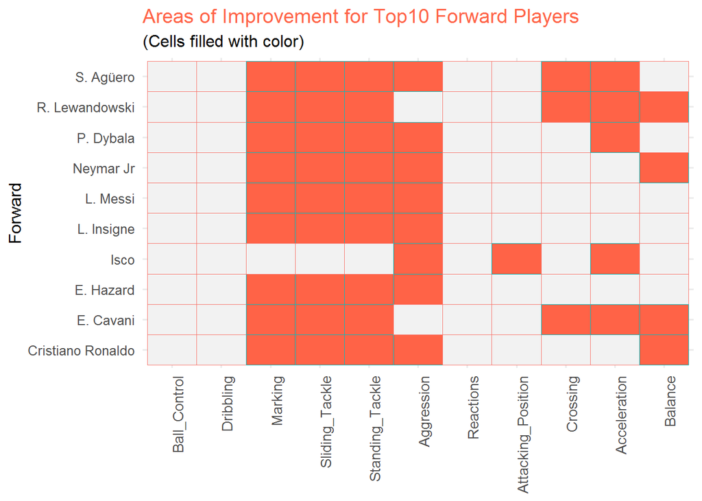

```r
g1
```

This plot shows areas of improvement for the top ten Forwards players. The cells filled with color indicate the areas selected player improvement. It is important to note that gaining attributes like Making and Sliding Tackle are not necessary to be a top performing Forward. Forward do very little defending in the grand scheme of a game so having this attribute would be a plus but we cannot consider them as a negative factor for Forwards.

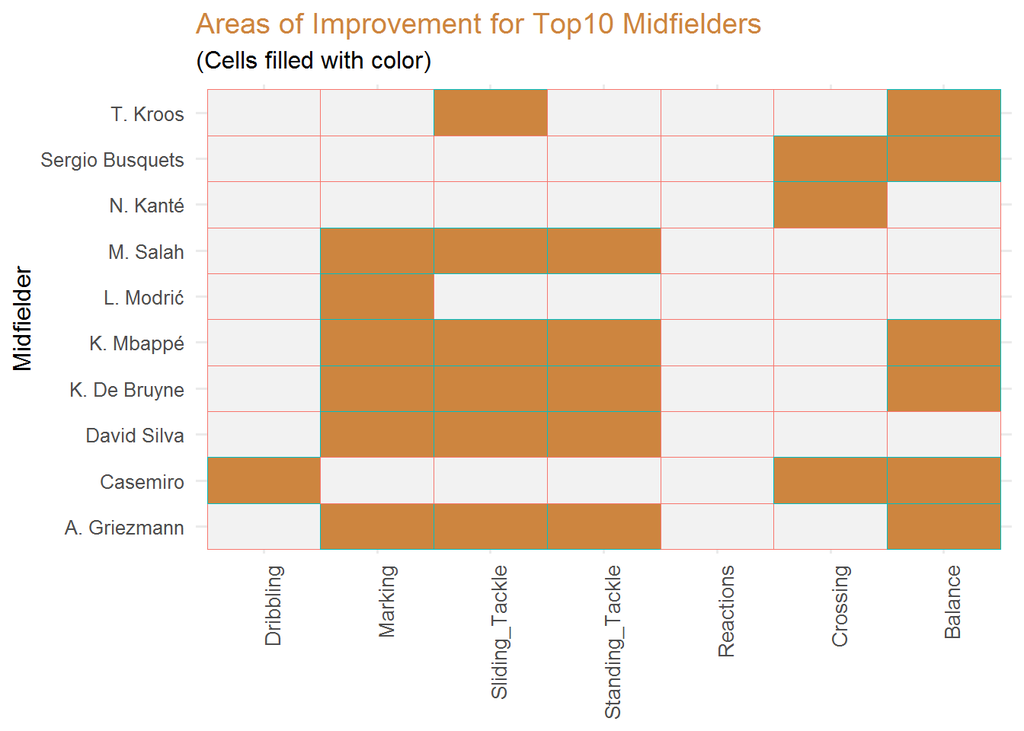

```r
g2
```

This plot shows areas of improvement for the top ten Midfielders. The cells filled with color indicate the areas selected for improvement. Midfielder are the most fully rounded players, they are supposed to be proficient in both attacking and defending.

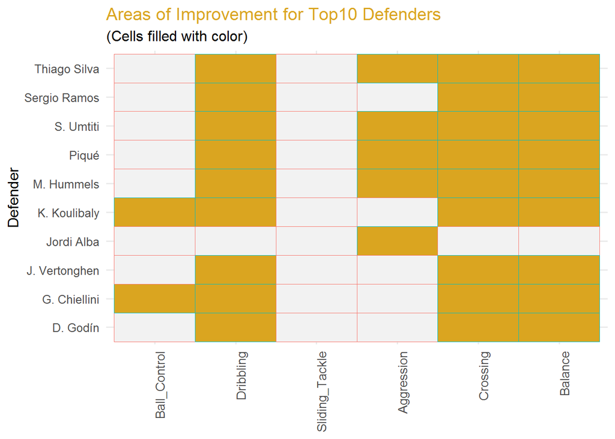

```r
g3
```

This plot shows areas of improvement for the top ten Defenders. The cells filled with color indicate the areas selected for improvement. Defenders hold the last line for teams, they are supposed to be aggressive but deliberate in how they use that aggression to win possession back for their teams.

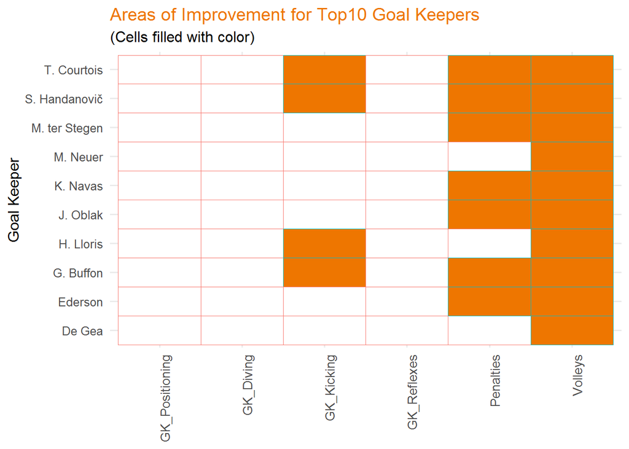

```r
g4
```

Q: How is a player’s skill set influence his potential? Can we predict a player’s potential based on his skills’ set?

```r
model_data <- fifa2019_unique %>% select(9,55:88) %>% filter(!is.na(Crossing))

#summary(model_data)

set.seed(1234) #keep this for reproducability
in.train <- createDataPartition(model_data$Potential, p=0.80, list=FALSE)
# 80% for training, one split
fifa_train <- model_data[in.train,]

fifa_test <- model_data[-in.train,]


#fifalm <- lm(Potential ~ ., data = fifa_train)

#summary(fifalm)

#fifa_pred <- predict(fifalm, fifa_test,method = "response")

#RMSE <- sqrt(mean((fifa_test$Potential - fifa_pred)^2))
#RMSE

fifa_train <- fifa_train %>% select(-c("Penalties","SlidingTackle","GKKicking","GKPositioning"))

fifalm <- lm(Potential ~ ., data = fifa_train)

summary(fifalm)
```

```
##
## Call:
## lm(formula = Potential ~ ., data = fifa_train)
##
## Residuals:
##      Min       1Q   Median       3Q      Max
## -18.8193  -3.3073  -0.2272   3.1238  18.3994
##
## Coefficients:
##                  Estimate Std. Error t value Pr(>|t|)
## (Intercept)     39.681194   0.536999  73.894  < 2e-16 ***
## Crossing        -0.084949   0.005408 -15.709  < 2e-16 ***
## Finishing        0.021211   0.006702   3.165 0.001554 **
## HeadingAccuracy  0.067305   0.005640  11.933  < 2e-16 ***
## ShortPassing     0.130580   0.009643  13.541  < 2e-16 ***
## Volleys         -0.024405   0.005863  -4.163 3.16e-05 ***
## Dribbling        0.100257   0.008531  11.753  < 2e-16 ***
## Curve            0.021983   0.005833   3.769 0.000165 ***
## FKAccuracy      -0.025074   0.005039  -4.976 6.58e-07 ***
## LongPassing     -0.050710   0.007099  -7.143 9.57e-13 ***
## BallControl      0.152874   0.010390  14.713  < 2e-16 ***
## Acceleration     0.073782   0.008016   9.205  < 2e-16 ***
## SprintSpeed      0.054657   0.007429   7.357 1.99e-13 ***
## Agility         -0.042202   0.005928  -7.119 1.14e-12 ***
## Reactions        0.179076   0.007778  23.024  < 2e-16 ***
## Balance         -0.026378   0.005340  -4.940 7.92e-07 ***
## ShotPower        0.039624   0.006042   6.558 5.64e-11 ***
## Jumping         -0.011184   0.004229  -2.645 0.008184 **
## Stamina         -0.029886   0.004901  -6.099 1.10e-09 ***
## Strength        -0.052330   0.005034 -10.395  < 2e-16 ***
## LongShots       -0.045062   0.006419  -7.020 2.32e-12 ***
## Aggression      -0.037344   0.004508  -8.285  < 2e-16 ***
## Interceptions   -0.052550   0.006439  -8.162 3.59e-16 ***
## Positioning     -0.082705   0.006333 -13.059  < 2e-16 ***
## Vision           0.030780   0.005854   5.258 1.48e-07 ***
## Composure        0.047686   0.006307   7.561 4.26e-14 ***
## Marking          0.026255   0.005180   5.069 4.06e-07 ***
## StandingTackle   0.074219   0.006670  11.127  < 2e-16 ***
## GKDiving         0.088714   0.011414   7.772 8.27e-15 ***
## GKHandling       0.053902   0.011337   4.755 2.01e-06 ***
## GKReflexes       0.066994   0.011270   5.944 2.84e-09 ***
## ---
## Signif. codes:  0 '***' 0.001 '**' 0.01 '*' 0.05 '.' 0.1 ' ' 1
##
## Residual standard error: 4.709 on 13688 degrees of freedom
## Multiple R-squared:   0.41,  Adjusted R-squared:  0.4087
## F-statistic: 317.1 on 30 and 13688 DF,  p-value: < 2.2e-16
```

```r
fifa_pred <- predict(fifalm, fifa_test,method = "response")

RMSE <- sqrt(mean((fifa_test$Potential - fifa_pred)^2))
RMSE
```

```
## [1] 4.651727
```

Conclusion and insights

We ran a few regression models but settled on fifalm model. We found that Penalties, sliding tackles, Goal Keeper kicking and Goal Keeper positioning were statistically insignificant in predicting the potential of a player. We tested the model on fifa_test and calculated an RMSE of 4.65. This model has R-squared value 0.41 which means that 41% of the variation of y has been explained by the independent variable. We tried to identify the most important attributes relating to player performance that contributes to a player’s potential. The attributes are crossing, finishing, heading accuracy, short passing, volleys, dribbling, curve, free kick accuracy, long passing, ball control, acceleration, sprint speed, agility, reactions, balance, shot power, jumping, stamina, strength, long shot, aggression, interception, positioning, vision, composure, marking, standing tackle, goal keeper diving, goal keeper handling, goal keeper reflexes.

Earlier we stated the competitive steps teams are undertaking to either remain at the top of their leagues or reduce the gap between the top of the league and the bottom from a financial prospective. The ability to predict the potential of a player given their attributes will prove insightful in two significant ways,

1. Development opportunities and
2. Player’s worth

And this is possible with enough historical data on what attributes that contribute to the success of players in various leagues. Teams can easily determine what attributes to develop based on player position on the field. Player worth is equally as important because being able to price a player based on future predicted potential will result in increased income for teams and player alike.